# Forschungspraktikum 1+2: Computational Social Science

Tutorial 07: Topic Modeling

Dr. Christian Czymara

We want to analyze the content of newspaper articles. We will work with a sample from the [AG News Classification Dataset](https://www.kaggle.com/datasets/amananandrai/ag-news-classification-dataset), which includes articles from more than 2,000 news sources over more than one year.

## 0. Getting Started

Before we begin, make sure the following R packages are installed and loaded.

- `dplyr` & `magrittr`: For data manipulation
- `quanteda`: For text processing
- `stm`: For running structural topic models

```r
packages <- c("dplyr", "magrittr", "quanteda", "stm")

# install if necessary
install.packages(setdiff(packages, rownames(installed.packages())))

# load
lapply(packages, library, character.only = TRUE)
```

```
## [[1]]
## [1] "dplyr"     "stats"     "graphics"  "grDevices" "utils"     "datasets"
## [7] "methods"   "base"
##
## [[2]]
## [1] "magrittr"  "dplyr"     "stats"     "graphics"  "grDevices" "utils"
## [7] "datasets"  "methods"   "base"
##
## [[3]]
##  [1] "quanteda"  "magrittr"  "dplyr"     "stats"     "graphics"  "grDevices"
##  [7] "utils"     "datasets"  "methods"   "base"
##
## [[4]]
##  [1] "stm"       "quanteda"  "magrittr"  "dplyr"     "stats"     "graphics"
##  [7] "grDevices" "utils"     "datasets"  "methods"   "base"
```

## 1. Data Preparation

### a) Data Import

Download the data set from this [repository](https://raw.githubusercontent.com/mhjabreel/CharCnn_Keras/master/data/ag_news_csv/train.csv) and import it into your R environment. Assign to an object called `newspaper_data_raw`. How many articles are included in the dataset? What other variables are included?

```r
newspaper_data_raw <- read.csv("https://raw.githubusercontent.com/mhjabreel/CharCnn_Keras/master/data/ag_news_csv/train.csv", header = F)

head(newspaper_data_raw)
```

```
##   V1                                                                        V2
## 1  3                         Wall St. Bears Claw Back Into the Black (Reuters)
## 2  3                       Carlyle Looks Toward Commercial Aerospace (Reuters)
## 3  3                           Oil and Economy Cloud Stocks' Outlook (Reuters)
## 4  3              Iraq Halts Oil Exports from Main Southern Pipeline (Reuters)
## 5  3 Oil prices soar to all-time record, posing new menace to US economy (AFP)
## 6  3                               Stocks End Up, But Near Year Lows (Reuters)
##                                                                                                                                                                                                                          V3
## 1                                                                                                                           Reuters - Short-sellers, Wall Street's dwindling\\band of ultra-cynics, are seeing green again.
## 2 Reuters - Private investment firm Carlyle Group,\\which has a reputation for making well-timed and occasionally\\controversial plays in the defense industry, has quietly placed\\its bets on another part of the market.
## 3                               Reuters - Soaring crude prices plus worries\\about the economy and the outlook for earnings are expected to\\hang over the stock market next week during the depth of the\\summer doldrums.
## 4                    Reuters - Authorities have halted oil export\\flows from the main pipeline in southern Iraq after\\intelligence showed a rebel militia could strike\\infrastructure, an oil official said on Saturday.
## 5                                                          AFP - Tearaway world oil prices, toppling records and straining wallets, present a new economic menace barely three months before the US presidential elections.
## 6                    Reuters - Stocks ended slightly higher on Friday\\but stayed near lows for the year as oil prices surged past  #36;46\\a barrel, offsetting a positive outlook from computer maker\\Dell Inc. (DELL.O)
```

### b) Sample

To speed things up, we will only analyze a fraction of the data. Use the following code to draw a two percent random sample:

```r
set.seed(1337)
newspaper_data_sample <- newspaper_data_raw[sample(1:nrow(newspaper_data_raw), size=nrow(newspaper_data_raw)*.02), ]
```

### c) Preprocessing

Based on this sample, we want to further prepare the text data. Check the following code, then execute it:

```r
newspaper_data_sample$title <- newspaper_data_sample$V2
newspaper_data_sample$description <- newspaper_data_sample$V3

newspaper_data_sample %<>%
  mutate(class = recode(V1,
                        `1` = "World",
                        `2` = "Sports",
                        `3` = "Business",
                        `4` = "Sci/Tech"))

table(newspaper_data_sample$class)
```

```
##
## Business Sci/Tech   Sports    World
##      598      594      619      589
```

```r
corpus <- corpus(as.character(newspaper_data_sample$description),
                 docvars = data.frame(genre = newspaper_data_sample$class
                 ))

# Tokenize
toks <- tokens(corpus, remove_punct = T,
               remove_numbers = T,
               remove_symbols = T,
               remove_separators = T,
               split_hyphens = T,
               remove_url = T,
               include_docvars = T)

toks <- tokens_remove(toks, stopwords(source = "stopwords-iso"), case_insensitive = TRUE)

toks <- tokens_wordstem(toks)

# Create DFM
newspapers_dfm <- dfm(toks)

newspapers_dfm <- newspapers_dfm[!rowSums(newspapers_dfm) == 0, ] # remove empty rows

nrow(newspapers_dfm)
```

```
## [1] 2400
```

```r
ncol(newspapers_dfm)
```

```
## [1] 7957
```

## 2. Structural Topic Modelling

### a) Run Model

Now that we have prepared the data, we can run a topic model. Use the `stm()` function to run a model with *20 topics* that includes `genre` as a document-level covariate for topic `prevalence`. This allows to examine how topic prevalence varies across genres. Run the STM model and use `summary()` to examine the topics. What themes emerge in the identified topics?

```r
k <- 20 # number of topics

set.seed(1337)
news_topics <- stm(newspapers_dfm,
                     K = k,
                     prevalence = ~ genre,
                     verbose = FALSE
                     )

summary(news_topics)
```

```
## A topic model with 20 topics, 2400 documents and a 7957 word dictionary.
```

```
## Topic 1 Top Words:
##       Highest Prob: technolog, compani, corp, maker, execut, oracl, peoplesoft
##       FREX: oracl, peoplesoft, technolog, info, infotyp, qcat, qtype
##       Lift: alvarion, antenna, asbesto, campus, ccia, clariion, juri
##       Score: technolog, peoplesoft, oracl, info, infotyp, qcat, qtype
## Topic 2 Top Words:
##       Highest Prob: airlin, pay, court, agre, feder, firm, judg
##       FREX: bankruptci, pay, airlin, delta, fund, judg, settl
##       Lift: 225m, 8.1billion, accord, aig.n, aplenti, aris, ata
##       Score: airlin, pay, bankruptci, fund, settl, judg, delta
## Topic 3 Top Words:
##       Highest Prob: win, olympic, york, sunday, team, athen, championship
##       FREX: athen, olympic, win, hamm, medal, athens, championship
##       Lift: activat, bull, cbc, dever, phelp, rattay, sports
##       Score: olympic, win, championship, medal, athen, champion, athens
## Topic 4 Top Words:
##       Highest Prob: hope, war, british, hostag, reuter, russian, russia
##       FREX: hope, hostag, beslan, chechen, sieg, crime, british
##       Lift: blair, cathol, chicken, clone, hate, karaok, kiev
##       Score: hostag, hope, chechen, beslan, sieg, russian, milosev
## Topic 5 Top Words:
##       Highest Prob: leader, issu, nuclear, european, arafat, reuter, offici
##       FREX: arafat, yasser, najaf, nuclear, sadr, issu, hospit
##       Lift: abandon, arabic, embargo, imam, inform, jazeera, loyal
##       Score: arafat, najaf, yasser, sadr, palestinian, nuclear, shrine
## Topic 6 Top Words:
##       Highest Prob: busi, phone, servic, compani, mobil, custom, provid
##       FREX: busi, phone, custom, mobil, provid, cell, electron
##       Lift: ambiti, blackberri, chinadotcom, consult, domain, hella, hewlett
##       Score: phone, busi, mobil, yahoo, custom, wireless, softwar
## Topic 7 Top Words:
##       Highest Prob: develop, user, comput, ibm, window, linux, compani
##       FREX: develop, server, supercomput, comput, linux, ibm, processor
##       Lift: #147, #148, anxious, maximum, micro, solari, wiki
##       Score: develop, user, server, ibm, window, comput, linux
## Topic 8 Top Words:
##       Highest Prob: oper, space, nasa, ship, corp, built, friday
##       FREX: nasa, built, oper, space, cnet, astronaut, panel
##       Lift: capsul, cnet, genesi, longhorn, punish, 1.2bn, 120m
##       Score: oper, nasa, space, built, ship, astronaut, privaci
```

[output cut: 45 more lines]

```
## Topic 18 Top Words:
##       Highest Prob: time, ipod, mortgag, apple, media, digit, player
##       FREX: time, mortgag, ipod, warner, kernel, peak, disney
##       Lift: lean, 1.2ghz, 1000s, 22mb, 240mb, 31b, 400mhz
##       Score: time, ipod, mortgag, kernel, apple, digit, lynn
## Topic 19 Top Words:
##       Highest Prob: game, season, sunday, #39, yard, coach, team
##       FREX: eli, game, season, yard, quarterback, touchdown, tennesse
##       Lift: acc, lion, louisvill, megson, 25th, 99th, a.m
##       Score: game, season, yard, quarterback, touchdown, man, coach
## Topic 20 Top Words:
##       Highest Prob: quot, set, final, day, cup, american, call
##       FREX: quot, seed, set, davenport, cup, final, hong
##       Lift: dementieva, elena, uefa, 17th, 28th, aachen, admir
##       Score: quot, cup, seed, final, set, davenport, lindsay
```

### b) Visualizing Topics

Use `plot()` to visualize topic prevalence, which identifies dominant topics.

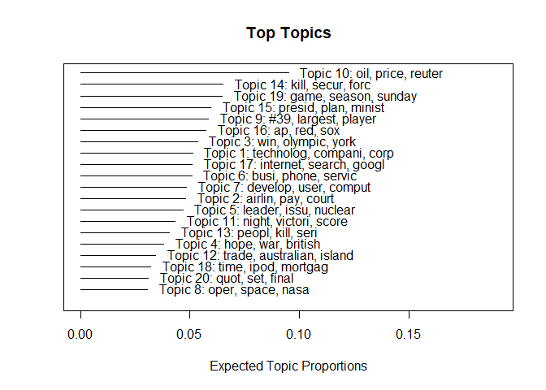

```r
plot(news_topics)
```

### c) Exploring Example Articles

Which articles are representative for *topic 10*? Use the `findThoughts()` function to extract the 15 most probable articles of this topic and show their titles (stored in `newspaper_data_sample$title`).

```r
findThoughts(news_topics, texts = newspaper_data_sample$title, n = 15, topics = 10)
```

```
##
##  Topic 10:
##       Krispy Kreme Drops Before Bell
##      CoTherix, Google Rise Before the Bell
##      Stocks Fall on Unwelcome 3M Results, Oil
##      Coke Profit Hurt by Sluggish Global Sales
##      Nikkei Seen Firming After 11,000 Cleared
##      FDA Rejects AstraZeneca's Exanta
##      Nike's 2nd-Quarter Earnings Jump
##      Food   Drink Woes Weigh on Eurostocks
##      Lowe's Reports 18 Pct. Hike in Profits
##      Shares Hit by Earnings, Dollar Falls
##      Oil Holds Firm, Heating Fuel Woes Persist (Reuters)
##      Oil Slides Another Dollar to 11-Week Low
##      Oil Prices Steady Above  #36;45 a Barrel (Reuters)
##      Maxim Dives 61 Pct on Drug Trial Result
##      Treasuries Rally as Job Doubts Reemerge
```

## 3. Testing for Differences Across Genres

Now we know which topics occur. But how does this differ across the four larger genres (e. g., World, Sports) provided in the original dataset?

### a) Estimating Effects

First, we need to run a regression that estimates the relationships between topic probabilities and the `genre` covariate. Use `stm`’s `estimateEffect()` function to run such a regression, based on the topic model of 2.a).

```r
genre_diff <- estimateEffect(1:k ~ genre,
                              news_topics,
                              meta = newspapers_dfm@docvars
                              )
```

### b) Visualizing Differences

Now we can check how each topic is associated with each genre using the `plot()` function with the option `method = "pointestimate"`. For example, which genre discusses *topic 10* most?

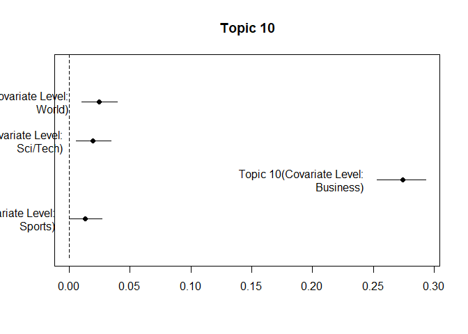

```r
plot(genre_diff,
     topics = 10,
     covariate = "genre",
     method = "pointestimate",
     main = "Topic 10"
     )
```

## 4. Choosing the Number of Topics

Finally, we want to analyze whether running a model with 20 topics was actually a good decision. Note that, usually, you would explore the number of topics *before* running the model.

### a) Searching for the Optimal Topic Number

Run `searchK()` to determine the optimal number of topics for this data. This involves examining various metrics, such as:

- Exclusivity: How distinct are the words for each topic?
  - *Maximize* (make topics more unique and clearly separated)
- Semantic Coherence: How often the most important words for a topic appear together in the data
  - *Maximize* (make topics more meaningful and interpretable)
- Heldout Likelihood: Tests how well the model predicts new, unseen data
  - *Maximize* (improve how well the model generalizes to new data)
- Bound: Measures how well the model fits the data
  - Typically *maximized* during training
- Lower bound: - A refined version of the Bound, which adjusts for comparison across models
  - *Maximize* (better model fit)
- Residual Dispersion: - Checks how much of the data’s variability remains unexplained by the topics
  - *Minimize* (reduce unexplained variability)

First, run `out <- convert(newspapers_dfm, to = "stm")`. Then, use `searchK()` on this `out` object. Experiment with different topic numbers (e. g., 10, 20, 30).

```r
out <- convert(newspapers_dfm, to = "stm")

set.seed(1337)
kresult <- searchK(out$documents,
                   out$vocab,
                   seq(10, 30, 10), # 10 to 30, in 10
                   prevalence = ~ genre,
                   data = out$meta,
                   verbose = FALSE
                   )
```

### b) Visualizing Search Results

`plot()` the results of 4.a) to evaluate the metrics. Interpret this plot.

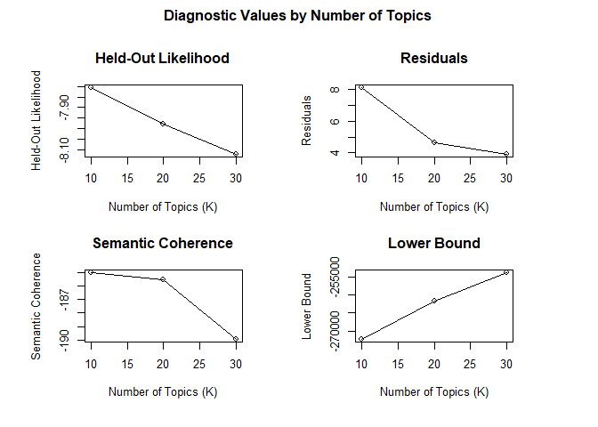

```r
plot(kresult)
```

### c) Evaluating Exclusivity and Semantic Coherence

Another way to decide on the number of topics is plotting *exclusivity* against *semantic coherence*. Exclusivity measures how unique a topic’s words are (high values meaning that the words are less likely to overlap with other topics) and semantic coherence measures how often a topic’s words appear together in the same text (high values implying that words are contextually related). By plotting these two metrics, we can balance the trade-off between distinctness (exclusivity) and interpretability (semantic coherence). A good choice for the number of topics typically optimizes both.

Run the following code and interpret the result. Which number of topics would you chose?

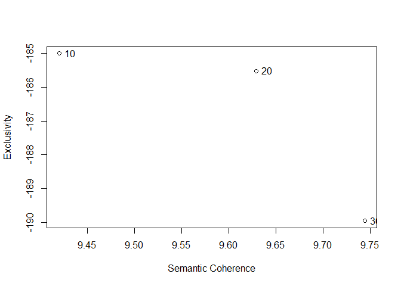

```r
plot(kresult$results$exclus, kresult$results$semcoh,
     xlab = "Semantic Coherence",
     ylab = "Exclusivity")


text(kresult$results$exclus, kresult$results$semcoh,
     labels = kresult$results$K, pos = 4)
```

### d) Evaluate Actual Topics

Finally, use `topicQuality()` to examine the quality of the chosen model including the 20 topics (i.e., the model actually used in 2.a)).

```r
topicQuality(model = news_topics,
             documents = newspapers_dfm)
```

```
##  [1] -123.6704 -173.0520 -160.4799 -208.2405 -201.3188 -151.0292 -171.7896
##  [8] -194.2473 -189.2353 -100.0455 -176.7289 -273.3928 -187.5682 -131.6040
## [15] -127.4009 -195.9016 -141.0948 -180.8249 -140.0619 -163.2572
##  [1] 9.705488 9.737267 9.654964 9.746572 9.727567 9.713128 9.708552 9.731546
##  [9] 9.542754 9.690833 9.627646 9.714337 9.637479 9.681663 9.749729 9.567171
## [17] 9.725531 9.727723 9.477036 9.878030
```

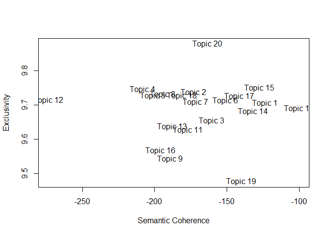